# Travel Package Purchase Prediction - Bagging and Boosting

We as a Data Scientist at "Visit with us" travel company have to analyze the customers' data and information to provide recommendations to the Policy Maker and Marketing Team and also build a model to predict the potential customer who is going to purchase the newly introduced travel package.

# Import Libraries

```python
import pandas as pd
import numpy as np
from sklearn import metrics
import matplotlib.pyplot as plt
%matplotlib inline
import warnings
warnings.filterwarnings('ignore')
import seaborn as sns
from sklearn.model_selection import train_test_split
from sklearn.model_selection import GridSearchCV
from sklearn import metrics
from sklearn.ensemble import BaggingClassifier, RandomForestClassifier
from sklearn.metrics import accuracy_score,precision_score,recall_score,f1_score
from sklearn.metrics import roc_auc_score
from sklearn.linear_model import LogisticRegression
from sklearn.model_selection import GridSearchCV
from sklearn import metrics
from sklearn.tree import DecisionTreeClassifier
from sklearn.ensemble import AdaBoostClassifier, GradientBoostingClassifier
#To install xgboost library use - !pip install xgboost
from xgboost import XGBClassifier
from sklearn.metrics import confusion_matrix
```

## We will load the `Tourism Data` (converted from xls to csv)

```python
tourismData = pd.read_csv("Tourism.csv")
```

## Let's print the head of the data frame

```python
tourismData.head(10) #several missing values!
```

|  | CustomerID | ProdTaken | Age | TypeofContact | CityTier | DurationOfPitch | Occupation | Gender | NumberOfPersonVisiting | NumberOfFollowups | ProductPitched | PreferredPropertyStar | MaritalStatus | NumberOfTrips | Passport | PitchSatisfactionScore | OwnCar | NumberOfChildrenVisiting | Designation | MonthlyIncome |
| --- | --- | --- | --- | --- | --- | --- | --- | --- | --- | --- | --- | --- | --- | --- | --- | --- | --- | --- | --- | --- |
| 0 | 200000 | 1 | 41.0 | Self Enquiry | 3 | 6.0 | Salaried | Female | 3 | 3.0 | Deluxe | 3.0 | Single | 1.0 | 1 | 2 | 1 | 0.0 | Manager | 20993.0 |
| 1 | 200001 | 0 | 49.0 | Company Invited | 1 | 14.0 | Salaried | Male | 3 | 4.0 | Deluxe | 4.0 | Divorced | 2.0 | 0 | 3 | 1 | 2.0 | Manager | 20130.0 |
| 2 | 200002 | 1 | 37.0 | Self Enquiry | 1 | 8.0 | Free Lancer | Male | 3 | 4.0 | Basic | 3.0 | Single | 7.0 | 1 | 3 | 0 | 0.0 | Executive | 17090.0 |
| 3 | 200003 | 0 | 33.0 | Company Invited | 1 | 9.0 | Salaried | Female | 2 | 3.0 | Basic | 3.0 | Divorced | 2.0 | 1 | 5 | 1 | 1.0 | Executive | 17909.0 |
| 4 | 200004 | 0 | NaN | Self Enquiry | 1 | 8.0 | Small Business | Male | 2 | 3.0 | Basic | 4.0 | Divorced | 1.0 | 0 | 5 | 1 | 0.0 | Executive | 18468.0 |
| 5 | 200005 | 0 | 32.0 | Company Invited | 1 | 8.0 | Salaried | Male | 3 | 3.0 | Basic | 3.0 | Single | 1.0 | 0 | 5 | 1 | 1.0 | Executive | 18068.0 |
| 6 | 200006 | 0 | 59.0 | Self Enquiry | 1 | 9.0 | Small Business | Female | 2 | 2.0 | Basic | 5.0 | Divorced | 5.0 | 1 | 2 | 1 | 1.0 | Executive | 17670.0 |
| 7 | 200007 | 0 | 30.0 | Self Enquiry | 1 | 30.0 | Salaried | Male | 3 | 3.0 | Basic | 3.0 | Married | 2.0 | 0 | 2 | 0 | 1.0 | Executive | 17693.0 |
| 8 | 200008 | 0 | 38.0 | Company Invited | 1 | 29.0 | Salaried | Male | 2 | 4.0 | Standard | 3.0 | Unmarried | 1.0 | 0 | 3 | 0 | 0.0 | Senior Manager | 24526.0 |
| 9 | 200009 | 0 | 36.0 | Self Enquiry | 1 | 33.0 | Small Business | Male | 3 | 3.0 | Deluxe | 3.0 | Divorced | 7.0 | 0 | 3 | 1 | 0.0 | Manager | 20237.0 |

## Let's print the shape of the data frame

```python
tourismData.shape
```

```
(4888, 20)
```

## Let's check the target variable counts

```python
tourismData['ProdTaken'].value_counts()
```

```
0    3968
1     920
Name: ProdTaken, dtype: int64
```

## Let's describe the data frame to see the mean, std etc

```python
tourismData.describe()
```

|  | CustomerID | ProdTaken | Age | CityTier | DurationOfPitch | NumberOfPersonVisiting | NumberOfFollowups | PreferredPropertyStar | NumberOfTrips | Passport | PitchSatisfactionScore | OwnCar | NumberOfChildrenVisiting | MonthlyIncome |
| --- | --- | --- | --- | --- | --- | --- | --- | --- | --- | --- | --- | --- | --- | --- |
| count | 4888.000000 | 4888.000000 | 4662.000000 | 4888.000000 | 4637.000000 | 4888.000000 | 4843.000000 | 4862.000000 | 4748.000000 | 4888.000000 | 4888.000000 | 4888.000000 | 4822.000000 | 4655.000000 |
| mean | 202443.500000 | 0.188216 | 37.622265 | 1.654255 | 15.490835 | 2.905074 | 3.708445 | 3.581037 | 3.236521 | 0.290917 | 3.078151 | 0.620295 | 1.187267 | 23619.853491 |
| std | 1411.188388 | 0.390925 | 9.316387 | 0.916583 | 8.519643 | 0.724891 | 1.002509 | 0.798009 | 1.849019 | 0.454232 | 1.365792 | 0.485363 | 0.857861 | 5380.698361 |
| min | 200000.000000 | 0.000000 | 18.000000 | 1.000000 | 5.000000 | 1.000000 | 1.000000 | 3.000000 | 1.000000 | 0.000000 | 1.000000 | 0.000000 | 0.000000 | 1000.000000 |
| 25% | 201221.750000 | 0.000000 | 31.000000 | 1.000000 | 9.000000 | 2.000000 | 3.000000 | 3.000000 | 2.000000 | 0.000000 | 2.000000 | 0.000000 | 1.000000 | 20346.000000 |
| 50% | 202443.500000 | 0.000000 | 36.000000 | 1.000000 | 13.000000 | 3.000000 | 4.000000 | 3.000000 | 3.000000 | 0.000000 | 3.000000 | 1.000000 | 1.000000 | 22347.000000 |
| 75% | 203665.250000 | 0.000000 | 44.000000 | 3.000000 | 20.000000 | 3.000000 | 4.000000 | 4.000000 | 4.000000 | 1.000000 | 4.000000 | 1.000000 | 2.000000 | 25571.000000 |
| max | 204887.000000 | 1.000000 | 61.000000 | 3.000000 | 127.000000 | 5.000000 | 6.000000 | 5.000000 | 22.000000 | 1.000000 | 5.000000 | 1.000000 | 3.000000 | 98678.000000 |

## Let's see the column types

```python
tourismData.info()  # many columns are of type object i.e. strings. These need to be converted to ordinal type
```

```
<class 'pandas.core.frame.DataFrame'>
RangeIndex: 4888 entries, 0 to 4887
Data columns (total 20 columns):
 #   Column                    Non-Null Count  Dtype
---  ------                    --------------  -----
 0   CustomerID                4888 non-null   int64
 1   ProdTaken                 4888 non-null   int64
 2   Age                       4662 non-null   float64
 3   TypeofContact             4863 non-null   object
 4   CityTier                  4888 non-null   int64
 5   DurationOfPitch           4637 non-null   float64
 6   Occupation                4888 non-null   object
 7   Gender                    4888 non-null   object
 8   NumberOfPersonVisiting    4888 non-null   int64
 9   NumberOfFollowups         4843 non-null   float64
 10  ProductPitched            4888 non-null   object
 11  PreferredPropertyStar     4862 non-null   float64
 12  MaritalStatus             4888 non-null   object
 13  NumberOfTrips             4748 non-null   float64
 14  Passport                  4888 non-null   int64
 15  PitchSatisfactionScore    4888 non-null   int64
 16  OwnCar                    4888 non-null   int64
 17  NumberOfChildrenVisiting  4822 non-null   float64
 18  Designation               4888 non-null   object
 19  MonthlyIncome             4655 non-null   float64
dtypes: float64(7), int64(7), object(6)
memory usage: 763.9+ KB
```

## Let's convert the columns with an 'object' datatype into categorical variables

```python
for feature in tourismData.columns: # Loop through all columns in the dataframe
    if tourismData[feature].dtype == 'object': # Only apply for columns with categorical strings
        tourismData[feature] = pd.Categorical(tourismData[feature])# Replace strings with an integer
```

```python
tourismData.head(10)
```

|  | CustomerID | ProdTaken | Age | TypeofContact | CityTier | DurationOfPitch | Occupation | Gender | NumberOfPersonVisiting | NumberOfFollowups | ProductPitched | PreferredPropertyStar | MaritalStatus | NumberOfTrips | Passport | PitchSatisfactionScore | OwnCar | NumberOfChildrenVisiting | Designation | MonthlyIncome |
| --- | --- | --- | --- | --- | --- | --- | --- | --- | --- | --- | --- | --- | --- | --- | --- | --- | --- | --- | --- | --- |
| 0 | 200000 | 1 | 41.0 | Self Enquiry | 3 | 6.0 | Salaried | Female | 3 | 3.0 | Deluxe | 3.0 | Single | 1.0 | 1 | 2 | 1 | 0.0 | Manager | 20993.0 |
| 1 | 200001 | 0 | 49.0 | Company Invited | 1 | 14.0 | Salaried | Male | 3 | 4.0 | Deluxe | 4.0 | Divorced | 2.0 | 0 | 3 | 1 | 2.0 | Manager | 20130.0 |
| 2 | 200002 | 1 | 37.0 | Self Enquiry | 1 | 8.0 | Free Lancer | Male | 3 | 4.0 | Basic | 3.0 | Single | 7.0 | 1 | 3 | 0 | 0.0 | Executive | 17090.0 |
| 3 | 200003 | 0 | 33.0 | Company Invited | 1 | 9.0 | Salaried | Female | 2 | 3.0 | Basic | 3.0 | Divorced | 2.0 | 1 | 5 | 1 | 1.0 | Executive | 17909.0 |
| 4 | 200004 | 0 | NaN | Self Enquiry | 1 | 8.0 | Small Business | Male | 2 | 3.0 | Basic | 4.0 | Divorced | 1.0 | 0 | 5 | 1 | 0.0 | Executive | 18468.0 |
| 5 | 200005 | 0 | 32.0 | Company Invited | 1 | 8.0 | Salaried | Male | 3 | 3.0 | Basic | 3.0 | Single | 1.0 | 0 | 5 | 1 | 1.0 | Executive | 18068.0 |
| 6 | 200006 | 0 | 59.0 | Self Enquiry | 1 | 9.0 | Small Business | Female | 2 | 2.0 | Basic | 5.0 | Divorced | 5.0 | 1 | 2 | 1 | 1.0 | Executive | 17670.0 |
| 7 | 200007 | 0 | 30.0 | Self Enquiry | 1 | 30.0 | Salaried | Male | 3 | 3.0 | Basic | 3.0 | Married | 2.0 | 0 | 2 | 0 | 1.0 | Executive | 17693.0 |
| 8 | 200008 | 0 | 38.0 | Company Invited | 1 | 29.0 | Salaried | Male | 2 | 4.0 | Standard | 3.0 | Unmarried | 1.0 | 0 | 3 | 0 | 0.0 | Senior Manager | 24526.0 |
| 9 | 200009 | 0 | 36.0 | Self Enquiry | 1 | 33.0 | Small Business | Male | 3 | 3.0 | Deluxe | 3.0 | Divorced | 7.0 | 0 | 3 | 1 | 0.0 | Manager | 20237.0 |

```python
print(tourismData.TypeofContact.value_counts())
print(tourismData.CityTier.value_counts())
print(tourismData.Occupation.value_counts())
print(tourismData.Gender.value_counts())
print(tourismData.ProductPitched.value_counts())
print(tourismData.MaritalStatus.value_counts())
print(tourismData.Designation.value_counts())
print(tourismData.Passport.value_counts())
```

```
Self Enquiry       3444
Company Invited    1419
Name: TypeofContact, dtype: int64
1    3190
3    1500
2     198
Name: CityTier, dtype: int64
Salaried          2368
Small Business    2084
Large Business     434
Free Lancer          2
Name: Occupation, dtype: int64
Male       2916
Female     1817
Fe Male     155
Name: Gender, dtype: int64
Basic           1842
Deluxe          1732
Standard         742
Super Deluxe     342
King             230
Name: ProductPitched, dtype: int64
Married      2340
Divorced      950
Single        916
Unmarried     682
Name: MaritalStatus, dtype: int64
Executive         1842
Manager           1732
Senior Manager     742
AVP                342
VP                 230
Name: Designation, dtype: int64
0    3466
1    1422
Name: Passport, dtype: int64
```

# Data Preprocessing

## Check for null values and replace them with median if feasible

```python
# checking for missing values
tourismData.isnull().sum()
```

```
CustomerID                    0
ProdTaken                     0
Age                         226
TypeofContact                25
CityTier                      0
DurationOfPitch             251
Occupation                    0
Gender                        0
NumberOfPersonVisiting        0
NumberOfFollowups            45
ProductPitched                0
PreferredPropertyStar        26
MaritalStatus                 0
NumberOfTrips               140
Passport                      0
PitchSatisfactionScore        0
OwnCar                        0
NumberOfChildrenVisiting     66
Designation                   0
MonthlyIncome               233
dtype: int64
```

## As shown above, there are lot of null values and they need to be imputed with the median value of that column

```python
tourismData["Age"] = tourismData["Age"].transform(
    lambda x: x.fillna(x.median())
)
```

```python
tourismData["DurationOfPitch"] = tourismData["DurationOfPitch"].transform(
    lambda x: x.fillna(x.median())
)
```

```python
tourismData["NumberOfFollowups"] = tourismData["NumberOfFollowups"].transform(
    lambda x: x.fillna(x.median())
)
```

```python
tourismData["PreferredPropertyStar"] = tourismData["PreferredPropertyStar"].transform(
    lambda x: x.fillna(x.median())
)
```

```python
tourismData["NumberOfTrips"] = tourismData["NumberOfTrips"].transform(
    lambda x: x.fillna(x.median())
)
```

```python
tourismData["NumberOfChildrenVisiting"] = tourismData["NumberOfChildrenVisiting"].transform(
    lambda x: x.fillna(x.median())
)
```

```python
tourismData["MonthlyIncome"] = tourismData["MonthlyIncome"].transform(
    lambda x: x.fillna(x.median())
)
```

```python
# Remove missing 'TypeofContact' rows
tourismData = tourismData[tourismData["TypeofContact"].notna()]
```

## Check for null values after imputing all columns

```python
# checking for missing values
tourismData.isnull().sum()
```

```
CustomerID                  0
ProdTaken                   0
Age                         0
TypeofContact               0
CityTier                    0
DurationOfPitch             0
Occupation                  0
Gender                      0
NumberOfPersonVisiting      0
NumberOfFollowups           0
ProductPitched              0
PreferredPropertyStar       0
MaritalStatus               0
NumberOfTrips               0
Passport                    0
PitchSatisfactionScore      0
OwnCar                      0
NumberOfChildrenVisiting    0
Designation                 0
MonthlyIncome               0
dtype: int64
```

## Replace 'Fe Male' as 'Female'

```python
tourismData["Gender"] = tourismData["Gender"].replace(
    ["Fe Male", "Fe Male"], "Female"
)
```

```python
print(tourismData.Gender.value_counts())
```

```
Male      2901
Female    1962
Name: Gender, dtype: int64
```

## Remove CustomerID column

```python
tourismData = tourismData.drop('CustomerID', 1)
```

## Find all object / category type of columns that influence the target variable

```python
tourismData.select_dtypes(include=["object", "category"]).columns.tolist()
```

```
['TypeofContact',
 'Occupation',
 'Gender',
 'ProductPitched',
 'MaritalStatus',
 'Designation']
```

# Exploratory Data Analysis - Univariate

## Let's build common methods for drawing charts

```python
# function to plot a boxplot and a histogram along the same scale.


def histogram_boxplot(data, feature, figsize=(12, 7), kde=False, bins=None):
    """
    Boxplot and histogram combined

    data: dataframe
    feature: dataframe column
    figsize: size of figure (default (12,7))
    kde: whether to show the density curve (default False)
    bins: number of bins for histogram (default None)
    """
    f2, (ax_box2, ax_hist2) = plt.subplots(
        nrows=2,  # Number of rows of the subplot grid= 2
        sharex=True,  # x-axis will be shared among all subplots
        gridspec_kw={"height_ratios": (0.25, 0.75)},
        figsize=figsize,
    )  # creating the 2 subplots
    sns.boxplot(
        data=data, x=feature, ax=ax_box2, showmeans=True, color="violet"
    )  # boxplot will be created and a star will indicate the mean value of the column
    sns.histplot(
        data=data, x=feature, kde=kde, ax=ax_hist2, bins=bins, palette="winter"
    ) if bins else sns.histplot(
        data=data, x=feature, kde=kde, ax=ax_hist2
    )  # For histogram
    ax_hist2.axvline(
        data[feature].mean(), color="green", linestyle="--"
    )  # Add mean to the histogram
    ax_hist2.axvline(
        data[feature].median(), color="black", linestyle="-"
    )  # Add median to the histogram
```

```python
# function to plot stacked bar chart


def stacked_barplot(data, predictor, target):
    """
    Print the category counts and plot a stacked bar chart

    data: dataframe
    predictor: independent variable
    target: target variable
    """
    count = data[predictor].nunique()
    sorter = data[target].value_counts().index[-1]
    tab1 = pd.crosstab(data[predictor], data[target], margins=True).sort_values(
        by=sorter, ascending=False
    )
    print(tab1)
    print("-" * 120)
    tab = pd.crosstab(data[predictor], data[target], normalize="index").sort_values(
        by=sorter, ascending=False
    )
    tab.plot(kind="bar", stacked=True, figsize=(count + 1, 5))
    plt.legend(
        loc="lower left",
        frameon=False,
    )
    plt.legend(loc="upper left", bbox_to_anchor=(1, 1))
    plt.show()
```

```python
# function to create labeled barplots


def labeled_barplot(data, feature, perc=False, n=None):
    """
    Barplot with percentage at the top

    data: dataframe
    feature: dataframe column
    perc: whether to display percentages instead of count (default is False)
    n: displays the top n category levels (default is None, i.e., display all levels)
    """

    total = len(data[feature])  # length of the column
    count = data[feature].nunique()
    if n is None:
        plt.figure(figsize=(count + 1, 5))
    else:
        plt.figure(figsize=(n + 1, 5))

    plt.xticks(rotation=90, fontsize=15)
    ax = sns.countplot(
        data=data,
        x=feature,
        palette="Paired",
        order=data[feature].value_counts().index[:n].sort_values(),
    )

    for p in ax.patches:
        if perc == True:
            label = "{:.1f}%".format(
                100 * p.get_height() / total
            )  # percentage of each class of the category
        else:
            label = p.get_height()  # count of each level of the category

        x = p.get_x() + p.get_width() / 2  # width of the plot
        y = p.get_height()  # height of the plot

        ax.annotate(
            label,
            (x, y),
            ha="center",
            va="center",
            size=12,
            xytext=(0, 5),
            textcoords="offset points",
        )  # annotate the percentage

    plt.show()  # show the plot
```

## Observations on Age

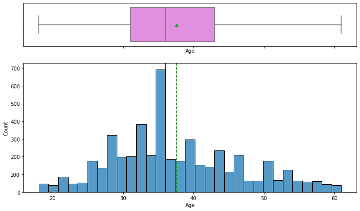

```python
histogram_boxplot(tourismData,'Age')
```

## Observations on Duration of Pitch

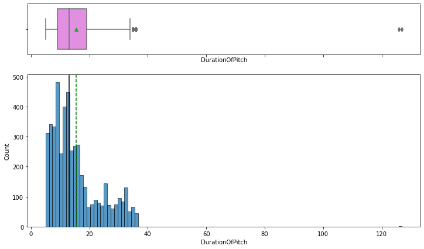

```python
histogram_boxplot(tourismData,'DurationOfPitch')
```

## Observations on Number of Persons Visiting

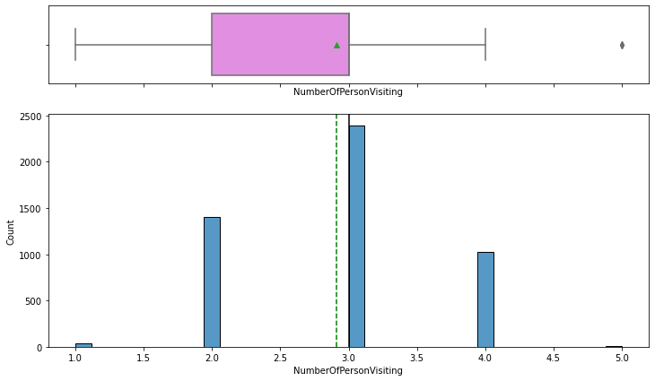

```python
histogram_boxplot(tourismData,'NumberOfPersonVisiting')
```

### As shown above, the average of persons visiting is around 3

## Observation on Number of Followups

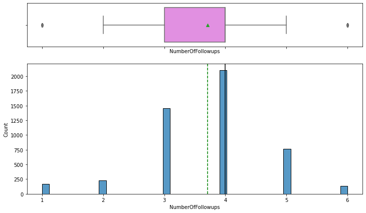

```python
histogram_boxplot(tourismData,'NumberOfFollowups')
```

### As shown above, the number of follow ups that a sales person is doing with a prospective customer is around 4 times

## Observation on Preferred Property Star

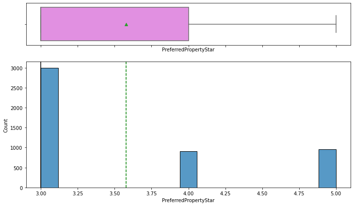

```python
histogram_boxplot(tourismData,'PreferredPropertyStar')
```

### As shown above, there seems to be high demand for properties with star rating of 3

## Observation on Number Of Trips

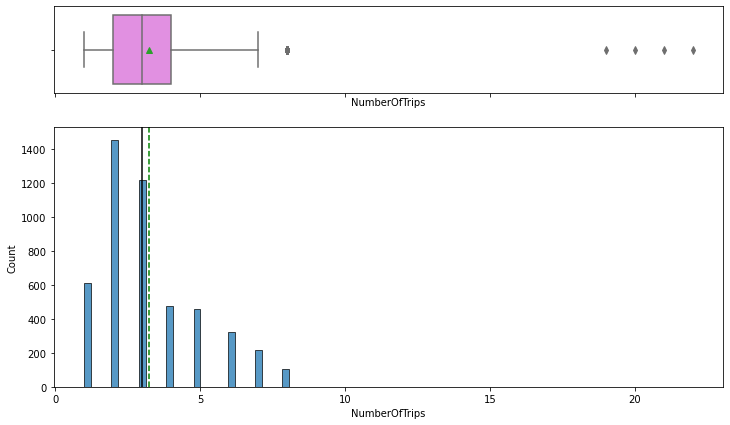

```python
histogram_boxplot(tourismData,'NumberOfTrips')
```

### As shown above, the number of times a customer is making trips with the travel package is around 2 to 3

## Observation on Pitch Satisfaction Score

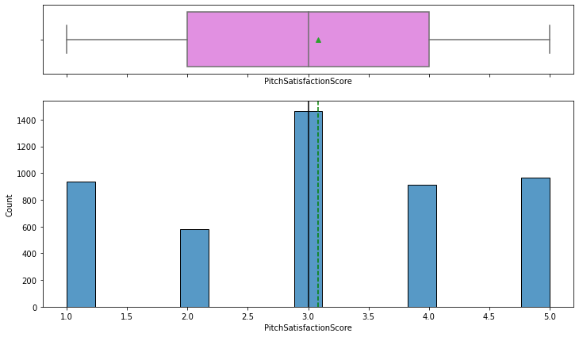

```python
histogram_boxplot(tourismData,'PitchSatisfactionScore')
```

### As shown above, the pitch satisfaction score is around 3 for most of the sales pitches that have happened for the travel packages

## Observation on Number of Children visiting

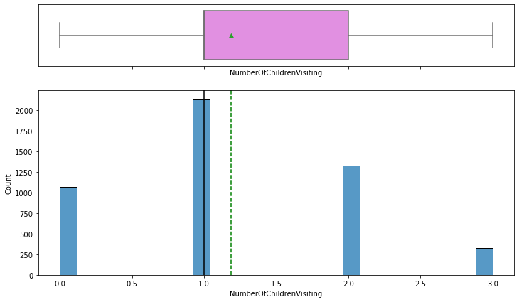

```python
histogram_boxplot(tourismData,'NumberOfChildrenVisiting')
```

### As shown above, the average number of children visiting with their parents is around 1

## Observation on Monthly Income

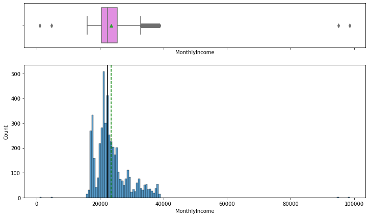

```python
histogram_boxplot(tourismData,'MonthlyIncome')
```

### As shown above, the average monthly income seems to be hovering around ~25K

## Observations on Type of Contact

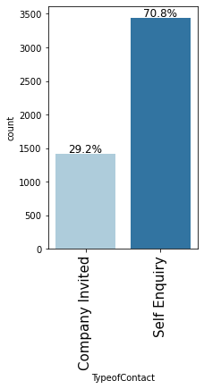

```python
labeled_barplot(tourismData, "TypeofContact", perc=True)
```

### As shown above, most of the travellers have made a self inquiry about the travel packages

## Observation on Occupation

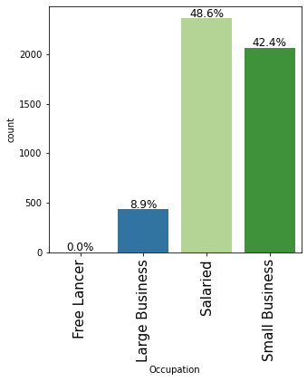

```python
labeled_barplot(tourismData, "Occupation", perc=True)
```

### As shown above, salaried customers seem to be more interested with small business owners next to them

## Observation on Gender

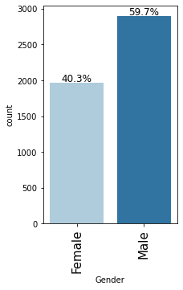

```python
labeled_barplot(tourismData, "Gender", perc=True)
```

### As shown above, males seem to be more in the customers list

## Observation on Product Pitched

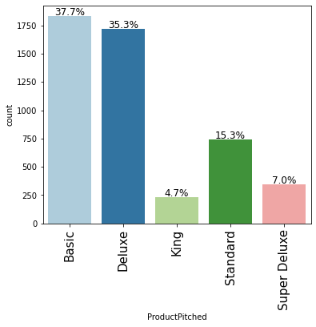

```python
labeled_barplot(tourismData, "ProductPitched", perc=True)
```

### As shown above, the Basic product seems to be pitched more compared to the others with Deluxe being the next one on line

## Observation on Marital Status

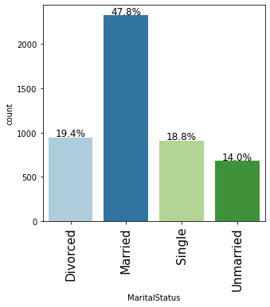

```python
labeled_barplot(tourismData, "MaritalStatus", perc=True)
```

### As shown above, married customers seem to be more in number for purchasing travel packages

## Observation on Designation

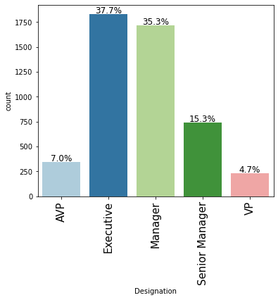

```python
labeled_barplot(tourismData, "Designation", perc=True)
```

### As shown above, executives and managers seem to be the highest in the list of customers purchasing the travel packages

# Exploratory Data Analysis - Bivariate

## Observation on Monthly Income, Number of follow ups and Pitch Satisfaction Score on ProdTaken

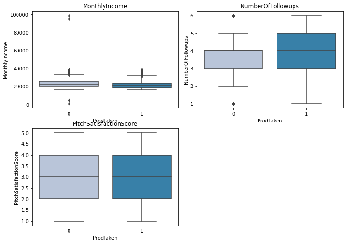

```python
cols = tourismData[['MonthlyIncome','NumberOfFollowups','PitchSatisfactionScore']].columns.tolist()
plt.figure(figsize=(10,10))

for i, variable in enumerate(cols):
                     plt.subplot(3,2,i+1)
                     sns.boxplot(tourismData["ProdTaken"],tourismData[variable],palette="PuBu")
                     plt.tight_layout()
                     plt.title(variable)
plt.show()
```

### As shown above, number of follow ups seems to be driving factor for customers purchasing the travel package as compared to Monthly Income / Pitch Satisfaction Score

## Observation on NumberOfChildrenVisiting, MaritalStatus

```
NumberOfChildrenVisiting   0.0   1.0   2.0  3.0   All
MaritalStatus
All                       1070  2135  1333  325  4863
Married                    492  1009   661  163  2325
Divorced                   222   415   241   66   944
Unmarried                   82   310   231   59   682
Single                     274   401   200   37   912
------------------------------------------------------------------------------------------------------------------------
```

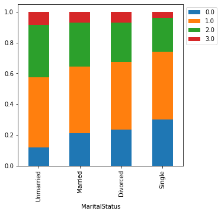

```python
stacked_barplot(tourismData, "MaritalStatus", "NumberOfChildrenVisiting")
```

## Observation on Occupation, Designation

```
Occupation      Free Lancer  Large Business  Salaried  Small Business   All
Designation
Executive                 2             196       921             713  1832
All                       2             434      2363            2064  4863
AVP                       0              18       174             150   342
Manager                   0             124       816             777  1717
Senior Manager            0              84       338             320   742
VP                        0              12       114             104   230
------------------------------------------------------------------------------------------------------------------------
```

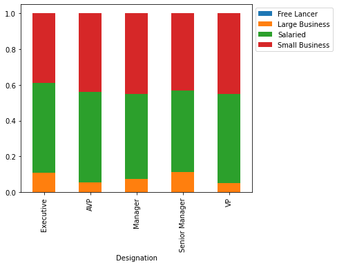

```python
stacked_barplot(tourismData, "Designation", "Occupation")
```

## Create dummy variables

```python
# creating dummy variables
tourismData = pd.get_dummies(
    tourismData,
    columns=tourismData.select_dtypes(include=["object", "category"]).columns.tolist(),
    drop_first=False,
)
```

```python
tourismData.info()
```

```
<class 'pandas.core.frame.DataFrame'>
Int64Index: 4863 entries, 0 to 4887
Data columns (total 35 columns):
 #   Column                         Non-Null Count  Dtype
---  ------                         --------------  -----
 0   ProdTaken                      4863 non-null   int64
 1   Age                            4863 non-null   float64
 2   CityTier                       4863 non-null   int64
 3   DurationOfPitch                4863 non-null   float64
 4   NumberOfPersonVisiting         4863 non-null   int64
 5   NumberOfFollowups              4863 non-null   float64
 6   PreferredPropertyStar          4863 non-null   float64
 7   NumberOfTrips                  4863 non-null   float64
 8   Passport                       4863 non-null   int64
 9   PitchSatisfactionScore         4863 non-null   int64
```

[output cut: 27 more lines]

## Let's create some predefined methods for evaluating models

```python
# defining a function to compute different metrics to check performance of a classification model built using sklearn
def model_performance_classification_sklearn(model, predictors, target):
    """
    Function to compute different metrics to check classification model performance

    model: classifier
    predictors: independent variables
    target: dependent variable
    """

    # predicting using the independent variables
    pred = model.predict(predictors)

    acc = accuracy_score(target, pred)  # to compute Accuracy
    recall = recall_score(target, pred)  # to compute Recall
    precision = precision_score(target, pred)  # to compute Precision
    f1 = f1_score(target, pred)  # to compute F1-score

    # creating a dataframe of metrics
    df_perf = pd.DataFrame(
        {
            "Accuracy": acc,
            "Recall": recall,
            "Precision": precision,
            "F1": f1,
        },
        index=[0],
    )

    return df_perf
```

```python
def confusion_matrix_sklearn(model, predictors, target):
      """
      To plot the confusion_matrix with percentages

      model: classifier
      predictors: independent variables
      target: dependent variable
      """
      y_pred = model.predict(predictors)
      cm = confusion_matrix(target, y_pred)
      labels = np.asarray(
          [
              ["{0:0.0f}".format(item) + "\n{0:.2%}".format(item / cm.flatten().sum())]
              for item in cm.flatten()
          ]
      ).reshape(2, 2)

      plt.figure(figsize=(6, 4))
      sns.heatmap(cm, annot=labels, fmt="")
      plt.ylabel("True label")
      plt.xlabel("Predicted label")
```

```python
## Function to create confusion matrix
def make_confusion_matrix(model,y_actual,labels=[1, 0]):
    '''
    model : classifier to predict values of X
    y_actual : ground truth

    '''
    y_predict = model.predict(X_test)
    cm=metrics.confusion_matrix( y_actual, y_predict, labels=[0, 1])
    df_cm = pd.DataFrame(cm, index = [i for i in ["Actual - No","Actual - Yes"]],
                  columns = [i for i in ['Predicted - No','Predicted - Yes']])
    group_counts = ["{0:0.0f}".format(value) for value in
                cm.flatten()]
    group_percentages = ["{0:.2%}".format(value) for value in
                         cm.flatten()/np.sum(cm)]
    labels = [f"{v1}\n{v2}" for v1, v2 in
              zip(group_counts,group_percentages)]
    labels = np.asarray(labels).reshape(2,2)
    plt.figure(figsize = (10,7))
    sns.heatmap(df_cm, annot=labels,fmt='')
    plt.ylabel('True label')
    plt.xlabel('Predicted label')
```

```python
##  Function to calculate different metric scores of the model - Accuracy, Recall and Precision
def get_metrics_score(model,flag=True):
    '''
    model : classifier to predict values of X

    '''
    # defining an empty list to store train and test results
    score_list=[]

    #Predicting on train and tests
    pred_train = model.predict(X_train)
    pred_test = model.predict(X_test)

    #Accuracy of the model
    train_acc = model.score(X_train,y_train)
    test_acc = model.score(X_test,y_test)

    #Recall of the model
    train_recall = metrics.recall_score(y_train,pred_train)
    test_recall = metrics.recall_score(y_test,pred_test)

    #Precision of the model
    train_precision = metrics.precision_score(y_train,pred_train)
    test_precision = metrics.precision_score(y_test,pred_test)

    score_list.extend((train_acc,test_acc,train_recall,test_recall,train_precision,test_precision))

    # If the flag is set to True then only the following print statements will be dispayed. The default value is set to True.
    if flag == True:
        print("Accuracy on training set : ",model.score(X_train,y_train))
        print("Accuracy on test set : ",model.score(X_test,y_test))
        print("Recall on training set : ",metrics.recall_score(y_train,pred_train))
        print("Recall on test set : ",metrics.recall_score(y_test,pred_test))
        print("Precision on training set : ",metrics.precision_score(y_train,pred_train))
        print("Precision on test set : ",metrics.precision_score(y_test,pred_test))

    return score_list # returning the list with train and test scores
```

## Split the data into train and test sets

```python
X = tourismData.drop("ProdTaken" , axis=1)
y = tourismData.pop("ProdTaken")
```

```python
X_train, X_test, y_train, y_test = train_test_split(X, y, test_size=.30, random_state=1,stratify=y)
```

## Building the model

- We are going to build 3 ensemble models here - DecisionTree, Bagging Classifier and Random Forest Classifier.
- First, let's build these models with default parameters and then use hyperparameter tuning to optimize the model performance.
- We will calculate all three metrics - Accuracy, Precision and Recall but the metric of interest here is recall.
- `Recall` - It gives the ratio of True positives to Actual positives, so high Recall implies low false negatives, i.e. low chances of predicting a defaulter as non defaulter

### Decision Tree Model

```python
dtree = DecisionTreeClassifier(random_state=1)
```

```python
dtree.fit(X_train, y_train)
```

```
DecisionTreeClassifier(random_state=1)
```

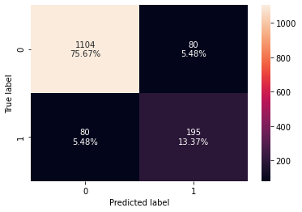

```python
confusion_matrix_sklearn(dtree, X_test, y_test)
```

```python
dtree_model_train_perf = model_performance_classification_sklearn(dtree, X_train, y_train)
print("Training performance \n",dtree_model_train_perf)
```

```
Training performance
    Accuracy  Recall  Precision   F1
0       1.0     1.0        1.0  1.0
```

```python
dtree_model_test_perf=model_performance_classification_sklearn(dtree, X_test, y_test)
print("Testing performance \n",dtree_model_test_perf)
```

```
Testing performance
    Accuracy    Recall  Precision        F1
0  0.890336  0.709091   0.709091  0.709091
```

### As shown above, Decision Tree is working well on the Training Data but not so well on the Testing data, the Recall score is 0.70

### Bagging Classifier

```python
#base_estimator for bagging classifier is a decision tree by default
bagging = BaggingClassifier(random_state=1)
bagging.fit(X_train,y_train)
```

```
BaggingClassifier(random_state=1)
```

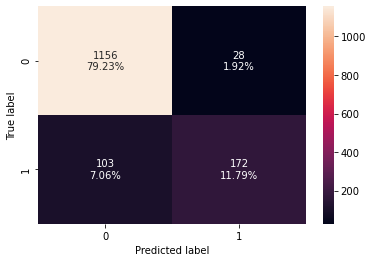

```python
confusion_matrix_sklearn(bagging, X_test, y_test)
```

```python
bagging_model_train_perf=model_performance_classification_sklearn(bagging, X_train, y_train)
print("Training performance \n",bagging_model_train_perf)
```

```
Training performance
    Accuracy    Recall  Precision        F1
0  0.992362  0.959502        1.0  0.979332
```

```python
bagging_model_test_perf=model_performance_classification_sklearn(bagging, X_test, y_test)
print("Testing performance \n",bagging_model_test_perf)
```

```
Testing performance
    Accuracy    Recall  Precision        F1
0  0.910212  0.625455       0.86  0.724211
```

### As shown above, bagging classifier has performed well on training data but not a good performance on the testing data as the recall score is 0.62 (103 were predicted as False Negative)

### Random Forest Classifier

```python
#Train the random forest classifier
rf =RandomForestClassifier(random_state=1)
rf.fit(X_train,y_train)
```

```
RandomForestClassifier(random_state=1)
```

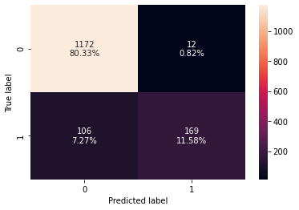

```python
confusion_matrix_sklearn(rf, X_test, y_test)
```

```python
rf_model_train_perf = model_performance_classification_sklearn(rf, X_train, y_train)
print("Training performance \n", rf_model_train_perf)
```

```
Training performance
    Accuracy  Recall  Precision   F1
0       1.0     1.0        1.0  1.0
```

```python
rf_model_test_perf = model_performance_classification_sklearn(rf, X_test, y_test)
print("Testing performance \n", rf_model_test_perf)
```

```
Testing performance
    Accuracy    Recall  Precision        F1
0  0.919123  0.614545   0.933702  0.741228
```

### As shown above, the recall score for test data is 0.61 for Random Forest Classifier though it has performed well for training data

## Comparing All Basic Models in Bagging - Decision Tree, BaggingClassifier, Random Forest

```python
models_train_comp_df = pd.concat(
    [dtree_model_train_perf.T,bagging_model_train_perf.T,rf_model_train_perf.T],
    axis=1,
)
models_train_comp_df.columns = [
    "Decision Tree",
    "Bagging Classifier",
    "Random Forest Classifier"
]
print("Training performance comparison:")
models_train_comp_df
```

```
Training performance comparison:
```

|  | Decision Tree | Bagging Classifier | Random Forest Classifier |
| --- | --- | --- | --- |
| Accuracy | 1.0 | 0.992362 | 1.0 |
| Recall | 1.0 | 0.959502 | 1.0 |
| Precision | 1.0 | 1.000000 | 1.0 |
| F1 | 1.0 | 0.979332 | 1.0 |

```python
models_test_comp_df = pd.concat(
    [dtree_model_test_perf.T, bagging_model_test_perf.T, rf_model_test_perf.T],
    axis=1,
)
models_test_comp_df.columns = [
    "Decision Tree",
    "Bagging Classifier",
    "Random Forest Classifier"
]
print("Testing performance comparison:")
models_test_comp_df
```

```
Testing performance comparison:
```

|  | Decision Tree | Bagging Classifier | Random Forest Classifier |
| --- | --- | --- | --- |
| Accuracy | 0.890336 | 0.910212 | 0.919123 |
| Recall | 0.709091 | 0.625455 | 0.614545 |
| Precision | 0.709091 | 0.860000 | 0.933702 |
| F1 | 0.709091 | 0.724211 | 0.741228 |

**With default parameters:**

- All three models - Decision Tree, Bagging classifiers as well as random forest classifier are performing well on training data (overfitting ?).
- All three models are giving similar performance in terms of accuracy but Decision Tree is giving better recall.

## Hyperparameter Tuning

### Tuning Decision Tree

```python
# Choose the type of classifier.
dtree_estimator = DecisionTreeClassifier(class_weight={0:0.83,1:0.17},random_state=1)

# Grid of parameters to choose from
parameters = {'max_depth': np.arange(2,30),
              'min_samples_leaf': [1, 2, 5, 7, 10],
              'max_leaf_nodes' : [2, 3, 5, 10,15],
              'min_impurity_decrease': [0.0001,0.001,0.01,0.1]
             }

# Type of scoring used to compare parameter combinations
scorer = metrics.make_scorer(metrics.recall_score)

# Run the grid search
grid_obj = GridSearchCV(dtree_estimator, parameters, scoring=scorer)
grid_obj = grid_obj.fit(X_train, y_train)

# Set the clf to the best combination of parameters
dtree_estimator = grid_obj.best_estimator_

# Fit the best algorithm to the data.
dtree_estimator.fit(X_train, y_train)
```

```
DecisionTreeClassifier(class_weight={0: 0.83, 1: 0.17}, max_depth=6,
                       max_leaf_nodes=15, min_impurity_decrease=0.0001,
                       min_samples_leaf=7, random_state=1)
```

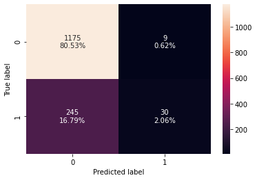

```python
confusion_matrix_sklearn(dtree_estimator, X_test,y_test)
```

```python
dtree_estimator_model_train_perf=model_performance_classification_sklearn(dtree_estimator, X_train,y_train)
print("Training performance \n",dtree_estimator_model_train_perf)
```

```
Training performance
    Accuracy    Recall  Precision        F1
0  0.837544  0.138629        1.0  0.243502
```

```python
dtree_estimator_model_test_perf=model_performance_classification_sklearn(dtree_estimator, X_test, y_test)
print("Testing performance \n",dtree_estimator_model_test_perf)
```

```
Testing performance
    Accuracy    Recall  Precision        F1
0  0.825908  0.109091   0.769231  0.191083
```

## As shown above, the accuracy of tuned decision tree has gone down but the Recall is very low on both training and testing data

### Bagging Classifier

**Some of the important hyperparameters available for bagging classifier are:**

- base_estimator: The base estimator to fit on random subsets of the dataset. If None(default), then the base estimator is a decision tree.
- n_estimators: The number of trees in the forest, default = 100.
- max_features: The number of features to consider when looking for the best split.
- bootstrap: Whether bootstrap samples are used when building trees. If False, the entire dataset is used to build each tree, default=True.
- bootstrap_features: If it is true, then features are drawn with replacement. Default value is False.
- max_samples: If bootstrap is True, then the number of samples to draw from X to train each base estimator. If None (default), then draw N samples, where N is the number of observations in the train data.
- oob_score: Whether to use out-of-bag samples to estimate the generalization accuracy, default=False.

```python
# Choose the type of classifier.
bagging_estimator_tuned = BaggingClassifier(random_state=1)

# Grid of parameters to choose from
## add from article
parameters = {'max_samples': [0.7,0.8,0.9,1],
              'max_features': [0.7,0.8,0.9,1],
              'n_estimators' : [10,20,30,40,50],
             }

# Type of scoring used to compare parameter combinations
acc_scorer = metrics.make_scorer(metrics.recall_score)

# Run the grid search
grid_obj = GridSearchCV(bagging_estimator_tuned, parameters, scoring=acc_scorer,cv=5)
grid_obj = grid_obj.fit(X_train, y_train)

# Set the clf to the best combination of parameters
bagging_estimator_tuned = grid_obj.best_estimator_

# Fit the best algorithm to the data.
bagging_estimator_tuned.fit(X_train, y_train)
```

```
BaggingClassifier(max_features=0.9, max_samples=0.9, n_estimators=50,
                  random_state=1)
```

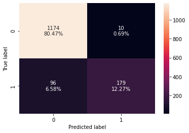

```python
confusion_matrix_sklearn(bagging_estimator_tuned, X_test,y_test)
```

```python
bagging_estimator_model_train_perf=model_performance_classification_sklearn(bagging_estimator_tuned, X_train,y_train)
print("Training performance \n",bagging_estimator_model_train_perf)
```

```
Training performance
    Accuracy  Recall  Precision   F1
0       1.0     1.0        1.0  1.0
```

```python
bagging_estimator_model_test_perf=model_performance_classification_sklearn(bagging_estimator_tuned, X_test, y_test)
print("Testing performance \n",bagging_estimator_model_test_perf)
```

```
Testing performance
    Accuracy    Recall  Precision        F1
0  0.927347  0.650909    0.94709  0.771552
```

### As shown above, we can see that after tuning the bagging classifier, the accuracy and recall are great in training data but the recall seems to be low in testing data

### Let's try using logistic regression as the base estimator for bagging classifier:

- Now, let's try and change the `base_estimator` of the bagging classifier, which is a decision tree by default.
- We will pass the logistic regression as the base estimator for bagging classifier.

```python
bagging_lr=BaggingClassifier(base_estimator=LogisticRegression(solver='liblinear',random_state=1,max_iter=1000),random_state=1)
bagging_lr.fit(X_train,y_train)
```

```
BaggingClassifier(base_estimator=LogisticRegression(max_iter=1000,
                                                    random_state=1,
                                                    solver='liblinear'),
                  random_state=1)
```

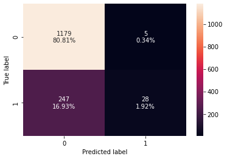

```python
confusion_matrix_sklearn(bagging_lr, X_test,y_test)
```

```python
bagging_lr_estimator_model_train_perf=model_performance_classification_sklearn(bagging_lr, X_train,y_train)
print("Training performance \n", bagging_lr_estimator_model_train_perf)
```

```
Training performance
    Accuracy    Recall  Precision        F1
0  0.822268  0.071651   0.836364  0.131994
```

```python
bagging_lr_estimator_model_test_perf=model_performance_classification_sklearn(bagging_lr, X_test, y_test)
print("Testing performance \n", bagging_lr_estimator_model_test_perf)
```

```
Testing performance
    Accuracy    Recall  Precision        F1
0  0.827279  0.101818   0.848485  0.181818
```

### As shown above, Bagging classifier with logistic regression as base_estimator is very low in Recall

### Random Forest Classifier

- n_estimators: The number of trees in the forest, default = 100.
- max_features: The number of features to consider when looking for the best split.
- class_weight: Weights associated with classes in the form {class_label: weight}.If not given, all classes are supposed to have weight one.
- For example: If the frequency of class 0 is 80% and the frequency of class 1 is 20% in the data, then class 0 will become the dominant class and the model will become biased toward the dominant classes. In this case, we can pass a dictionary {0:0.2,1:0.8} to the model to specify the weight of each class and the random forest will give more weightage to class 1.
- bootstrap: Whether bootstrap samples are used when building trees. If False, the entire dataset is used to build each tree, default=True.
- max_samples: If bootstrap is True, then the number of samples to draw from X to train each base estimator. If None (default), then draw N samples, where N is the number of observations in the train data.
- oob_score: Whether to use out-of-bag samples to estimate the generalization accuracy, default=False.

```python
# Choose the type of classifier.
rf_estimator_tuned = RandomForestClassifier(random_state=1)

# Grid of parameters to choose from
## add from article
parameters = {"n_estimators": [150,200,250],
    "min_samples_leaf": np.arange(5, 10),
    "max_features": np.arange(0.2, 0.7, 0.1),
    "max_samples": np.arange(0.3, 0.7, 0.1),
             }

# Type of scoring used to compare parameter combinations
acc_scorer = metrics.make_scorer(metrics.recall_score)

# Run the grid search
grid_obj = GridSearchCV(rf_estimator_tuned, parameters, scoring=acc_scorer,cv=5)
grid_obj = grid_obj.fit(X_train, y_train)

# Set the clf to the best combination of parameters
rf_estimator_tuned = grid_obj.best_estimator_

# Fit the best algorithm to the data.
rf_estimator_tuned.fit(X_train, y_train)
```

```
RandomForestClassifier(max_features=0.6000000000000001,
                       max_samples=0.6000000000000001, min_samples_leaf=5,
                       n_estimators=200, random_state=1)
```

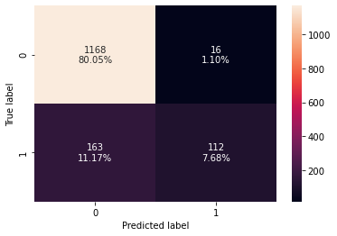

```python
confusion_matrix_sklearn(rf_estimator_tuned, X_test,y_test)
```

```python
rf_estimator_tuned_model_train_perf=model_performance_classification_sklearn(rf_estimator_tuned, X_train,y_train)
print("Training performance \n", rf_estimator_tuned_model_train_perf)
```

```
Training performance
    Accuracy   Recall  Precision        F1
0  0.911281  0.55296   0.959459  0.701581
```

```python
rf_estimator_tuned_model_test_perf=model_performance_classification_sklearn(rf_estimator_tuned, X_test, y_test)
print("Testing performance \n", rf_estimator_tuned_model_test_perf)
```

```
Testing performance
    Accuracy    Recall  Precision        F1
0  0.877313  0.407273      0.875  0.555831
```

### As shown above, we can see that the Recall is better in training compared to test but both seem to be low

### Let's try using class_weights for random forest:

```python
# Choose the type of classifier.
rf_estimator_weighted = RandomForestClassifier(random_state=1)

# Grid of parameters to choose from
## add from article
parameters = {
    "class_weight": [{0: 0.7, 1: 0.3}],
    "n_estimators": [100,150,200,250],
    "min_samples_leaf": np.arange(5, 10),
    "max_features": np.arange(0.2, 0.7, 0.1),
    "max_samples": np.arange(0.3, 0.7, 0.1),
}

# Type of scoring used to compare parameter combinations
acc_scorer = metrics.make_scorer(metrics.recall_score)

# Run the grid search
grid_obj = GridSearchCV(rf_estimator_weighted, parameters, scoring=acc_scorer,cv=5)
grid_obj = grid_obj.fit(X_train, y_train)

# Set the clf to the best combination of parameters
rf_estimator_weighted = grid_obj.best_estimator_

# Fit the best algorithm to the data.
rf_estimator_weighted.fit(X_train, y_train)
```

```
RandomForestClassifier(class_weight={0: 0.7, 1: 0.3},
                       max_features=0.6000000000000001,
                       max_samples=0.6000000000000001, min_samples_leaf=5,
                       random_state=1)
```

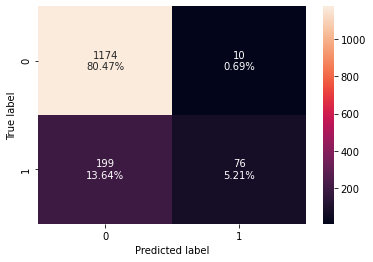

```python
confusion_matrix_sklearn(rf_estimator_weighted, X_test,y_test)
```

```python
rf_estimator_weighted_model_train_perf=model_performance_classification_sklearn(rf_estimator_weighted, X_train,y_train)
print("Training performance \n", rf_estimator_weighted_model_train_perf)
```

```
Training performance
    Accuracy    Recall  Precision        F1
0  0.878085  0.362928   0.974895  0.528944
```

```python
rf_estimator_weighted_model_test_perf=model_performance_classification_sklearn(rf_estimator_weighted, X_test, y_test)
print("Testing performance \n", rf_estimator_weighted_model_test_perf)
```

```
Testing performance
    Accuracy    Recall  Precision        F1
0  0.856751  0.276364   0.883721  0.421053
```

### Comparing all models till now

```python
# defining list of training models
models_train_comp_df = pd.concat(
    [
        dtree_model_train_perf.T,
        bagging_model_train_perf.T,
        rf_model_train_perf.T,
        dtree_estimator_model_train_perf.T,
        bagging_estimator_model_train_perf.T,
        bagging_lr_estimator_model_train_perf.T,
        rf_estimator_tuned_model_train_perf.T,
        rf_estimator_weighted_model_train_perf.T
    ],
    axis=1,
)
models_train_comp_df.columns = [
    "Decision Tree - Default",
    "Bagging Classifier - Default",
    "Random Forest Classifier - Default",
    "Decision Tree - Class Weight",
    "Bagging Classifier - Tuned",
    "Bagging Classifier - LR Tuned",
    "Random Forest Classifier - Tuned",
    "Random Forest Classifier - Class Weight"
]
print("Training performance comparison:")
models_train_comp_df
```

```
Training performance comparison:
```

|  | Decision Tree - Default | Bagging Classifier - Default | Random Forest Classifier - Default | Decision Tree - Class Weight | Bagging Classifier - Tuned | Bagging Classifier - LR Tuned | Random Forest Classifier - Tuned | Random Forest Classifier - Class Weight |
| --- | --- | --- | --- | --- | --- | --- | --- | --- |
| Accuracy | 1.0 | 0.992362 | 1.0 | 0.837544 | 1.0 | 0.822268 | 0.911281 | 0.878085 |
| Recall | 1.0 | 0.959502 | 1.0 | 0.138629 | 1.0 | 0.071651 | 0.552960 | 0.362928 |
| Precision | 1.0 | 1.000000 | 1.0 | 1.000000 | 1.0 | 0.836364 | 0.959459 | 0.974895 |
| F1 | 1.0 | 0.979332 | 1.0 | 0.243502 | 1.0 | 0.131994 | 0.701581 | 0.528944 |

```python
# defining list of testing models
models_test_comp_df = pd.concat(
    [
        dtree_model_test_perf.T,
        bagging_model_test_perf.T,
        rf_model_test_perf.T,
        dtree_estimator_model_test_perf.T,
        bagging_estimator_model_test_perf.T,
        bagging_lr_estimator_model_test_perf.T,
        rf_estimator_tuned_model_test_perf.T,
        rf_estimator_weighted_model_test_perf.T
    ],
    axis=1,
)
models_test_comp_df.columns = [
    "Decision Tree - Default",
    "Bagging Classifier - Default",
    "Random Forest Classifier - Default",
    "Decision Tree - Class Weight",
    "Bagging Classifier - Tuned",
    "Bagging Classifier - LR Tuned",
    "Random Forest Classifier - Tuned",
    "Random Forest Classifier - Class Weight"
]
print("Testing performance comparison:")
models_test_comp_df
```

```
Testing performance comparison:
```

|  | Decision Tree - Default | Bagging Classifier - Default | Random Forest Classifier - Default | Decision Tree - Class Weight | Bagging Classifier - Tuned | Bagging Classifier - LR Tuned | Random Forest Classifier - Tuned | Random Forest Classifier - Class Weight |
| --- | --- | --- | --- | --- | --- | --- | --- | --- |
| Accuracy | 0.890336 | 0.910212 | 0.919123 | 0.825908 | 0.927347 | 0.827279 | 0.877313 | 0.856751 |
| Recall | 0.709091 | 0.625455 | 0.614545 | 0.109091 | 0.650909 | 0.101818 | 0.407273 | 0.276364 |
| Precision | 0.709091 | 0.860000 | 0.933702 | 0.769231 | 0.947090 | 0.848485 | 0.875000 | 0.883721 |
| F1 | 0.709091 | 0.724211 | 0.741228 | 0.191083 | 0.771552 | 0.181818 | 0.555831 | 0.421053 |

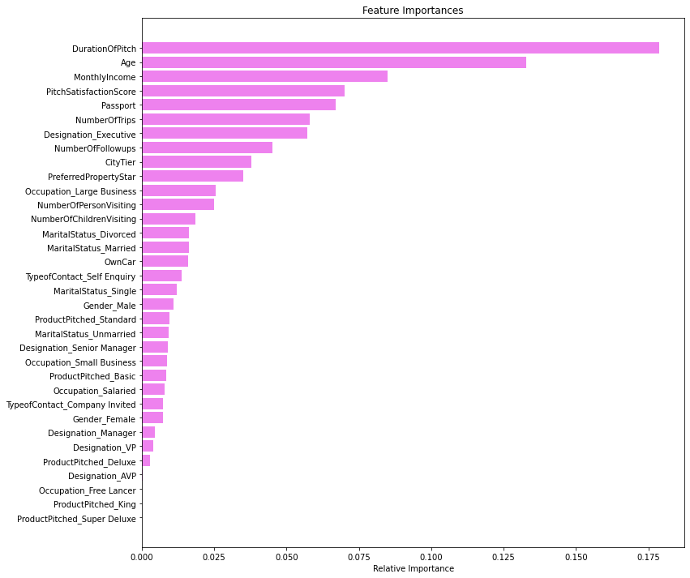

```python
importances = dtree.feature_importances_
indices = np.argsort(importances)
feature_names = list(X.columns)

plt.figure(figsize=(12,12))
plt.title('Feature Importances')
plt.barh(range(len(indices)), importances[indices], color='violet', align='center')
plt.yticks(range(len(indices)), [feature_names[i] for i in indices])
plt.xlabel('Relative Importance')
plt.show()
```

### DurationOfPitch, Age seem to be the main factors with also the MonthlyIncome

# Boosting

## AdaBoostClassifier

```python
abc = AdaBoostClassifier(random_state=1)
abc.fit(X_train,y_train)
```

```
AdaBoostClassifier(random_state=1)
```

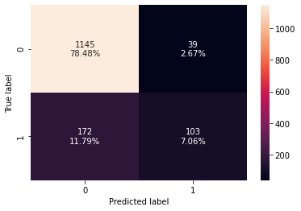

```python
confusion_matrix_sklearn(abc, X_test,y_test)
```

```python
abc_model_train_perf = model_performance_classification_sklearn(abc, X_train,y_train)
print("Training performance \n", abc_model_train_perf)
```

```
Training performance
    Accuracy    Recall  Precision        F1
0  0.851645  0.358255   0.712074  0.476684
```

```python
abc_model_test_perf = model_performance_classification_sklearn(abc, X_test,y_test)
print("Testing performance \n", abc_model_test_perf)
```

```
Testing performance
    Accuracy    Recall  Precision        F1
0   0.85538  0.374545   0.725352  0.494005
```

### As shown above, the accuracy seems to be good but the Recall is low for both training and test data with AdaBoostClassifier

## Gradient Boosting Classifier

```python
gbc = GradientBoostingClassifier(random_state=1)
gbc.fit(X_train,y_train)
```

```
GradientBoostingClassifier(random_state=1)
```

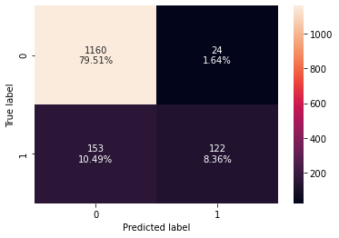

```python
confusion_matrix_sklearn(gbc, X_test,y_test)
```

```python
gbc_model_train_perf = model_performance_classification_sklearn(gbc, X_train,y_train)
print("Training performance \n", gbc_model_train_perf)
```

```
Training performance
    Accuracy   Recall  Precision        F1
0   0.88631  0.47352    0.86119  0.611055
```

```python
gbc_model_test_perf = model_performance_classification_sklearn(gbc, X_test,y_test)
print("Testing performance \n", gbc_model_test_perf)
```

```
Testing performance
    Accuracy    Recall  Precision        F1
0  0.878684  0.443636   0.835616  0.579572
```

### As shown Gradient Boosting Classifer also has good accuracy but Recall is low

## Hyperparameter Tuning - Boosting

## AdaBoost Classifier

```python
# Choose the type of classifier.
abc_tuned = AdaBoostClassifier(random_state=1)

# Grid of parameters to choose from
## add from article
parameters = {
    #Let's try different max_depth for base_estimator
    "base_estimator":[DecisionTreeClassifier(max_depth=1, random_state=1),DecisionTreeClassifier(max_depth=2, random_state=1),DecisionTreeClassifier(max_depth=3, random_state=1)],
    "n_estimators": np.arange(10,110,10),
    "learning_rate":np.arange(0.1,2,0.1)
}

# Type of scoring used to compare parameter combinations
acc_scorer = metrics.make_scorer(metrics.recall_score)

# Run the grid search
grid_obj = GridSearchCV(abc_tuned, parameters, scoring=acc_scorer,cv=5)
grid_obj = grid_obj.fit(X_train, y_train)

# Set the clf to the best combination of parameters
abc_tuned = grid_obj.best_estimator_

# Fit the best algorithm to the data.
abc_tuned.fit(X_train, y_train)
```

```
AdaBoostClassifier(base_estimator=DecisionTreeClassifier(max_depth=3,
                                                         random_state=1),
                   learning_rate=1.5000000000000002, n_estimators=100,
                   random_state=1)
```

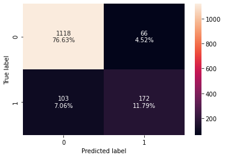

```python
confusion_matrix_sklearn(abc_tuned, X_test,y_test)
```

```python
abc_tuned_model_train_perf = model_performance_classification_sklearn(abc_tuned, X_train,y_train)
print("Training performance \n", abc_tuned_model_train_perf)
```

```
Training performance
    Accuracy    Recall  Precision        F1
0  0.987368  0.953271     0.9792  0.966062
```

```python
abc_tuned_model_test_perf = model_performance_classification_sklearn(abc_tuned, X_test,y_test)
print("Testing performance \n", abc_tuned_model_test_perf)
```

```
Testing performance
    Accuracy    Recall  Precision        F1
0  0.884167  0.625455   0.722689  0.670565
```

### As shown above, the AdaBoostClassifier tuned model has performed well on training data and is average on testing data

## Gradient Boosting Classifier

```python
# Choose the type of classifier.
gbc_tuned = GradientBoostingClassifier(init=AdaBoostClassifier(random_state=1),random_state=1)

# Grid of parameters to choose from
## add from article
parameters = {
    "n_estimators": [100,150,200,250],
    "subsample":[0.8,0.9,1],
    "max_features":[0.7,0.8,0.9,1]
}

# Type of scoring used to compare parameter combinations
acc_scorer = metrics.make_scorer(metrics.recall_score)

# Run the grid search
grid_obj = GridSearchCV(gbc_tuned, parameters, scoring=acc_scorer,cv=5)
grid_obj = grid_obj.fit(X_train, y_train)

# Set the clf to the best combination of parameters
gbc_tuned = grid_obj.best_estimator_

# Fit the best algorithm to the data.
gbc_tuned.fit(X_train, y_train)
```

```
GradientBoostingClassifier(init=AdaBoostClassifier(random_state=1),
                           max_features=0.9, n_estimators=250, random_state=1,
                           subsample=0.8)
```

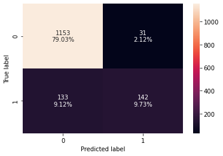

```python
confusion_matrix_sklearn(gbc_tuned, X_test,y_test)
```

```python
gbc_tuned_model_train_perf = model_performance_classification_sklearn(gbc_tuned, X_train,y_train)
print("Training performance \n", gbc_tuned_model_train_perf)
```

```
Training performance
    Accuracy    Recall  Precision        F1
0  0.923325  0.632399   0.941995  0.756757
```

```python
gbc_tuned_model_test_perf = model_performance_classification_sklearn(gbc_tuned, X_test,y_test)
print("Testing performance \n", gbc_tuned_model_test_perf)
```

```
Testing performance
    Accuracy    Recall  Precision        F1
0  0.887594  0.516364   0.820809  0.633929
```

### As shown above, accuracy is good for both training and testing data but recall is lower in testing data

## Compare all boosting models till now

```python
# defining list of training models
boost_models_train_comp_df = pd.concat(
    [
        abc_model_train_perf.T,
        gbc_model_train_perf.T,
        abc_tuned_model_train_perf.T,
        gbc_tuned_model_train_perf.T
    ],
    axis=1,
)
boost_models_train_comp_df.columns = [
    "AdaBoost - Default",
    "Gradient Boosting - Default",
    "AdaBoost - Tuned",
    "Gradient Boosting - Tuned"
]
print("Training performance comparison:")
boost_models_train_comp_df
```

```
Training performance comparison:
```

|  | AdaBoost - Default | Gradient Boosting - Default | AdaBoost - Tuned | Gradient Boosting - Tuned |
| --- | --- | --- | --- | --- |
| Accuracy | 0.851645 | 0.886310 | 0.987368 | 0.923325 |
| Recall | 0.358255 | 0.473520 | 0.953271 | 0.632399 |
| Precision | 0.712074 | 0.861190 | 0.979200 | 0.941995 |
| F1 | 0.476684 | 0.611055 | 0.966062 | 0.756757 |

```python
# defining list of testing models
boost_models_test_comp_df = pd.concat(
    [
        abc_model_test_perf.T,
        gbc_model_test_perf.T,
        abc_tuned_model_test_perf.T,
        gbc_tuned_model_test_perf.T
    ],
    axis=1,
)
boost_models_test_comp_df.columns = [
    "AdaBoost - Default",
    "Gradient Boosting - Default",
    "AdaBoost - Tuned",
    "Gradient Boosting - Tuned"
]
print("Testing performance comparison:")
boost_models_test_comp_df
```

```
Testing performance comparison:
```

|  | AdaBoost - Default | Gradient Boosting - Default | AdaBoost - Tuned | Gradient Boosting - Tuned |
| --- | --- | --- | --- | --- |
| Accuracy | 0.855380 | 0.878684 | 0.884167 | 0.887594 |
| Recall | 0.374545 | 0.443636 | 0.625455 | 0.516364 |
| Precision | 0.725352 | 0.835616 | 0.722689 | 0.820809 |
| F1 | 0.494005 | 0.579572 | 0.670565 | 0.633929 |

### As shown above, AdaBoost - Tuned model has performed well in both training and testing data

### Checking the feature importance for Ada Boost - Tuned model as it has shown good accuracy and recall values compared to other models in both training and testing data

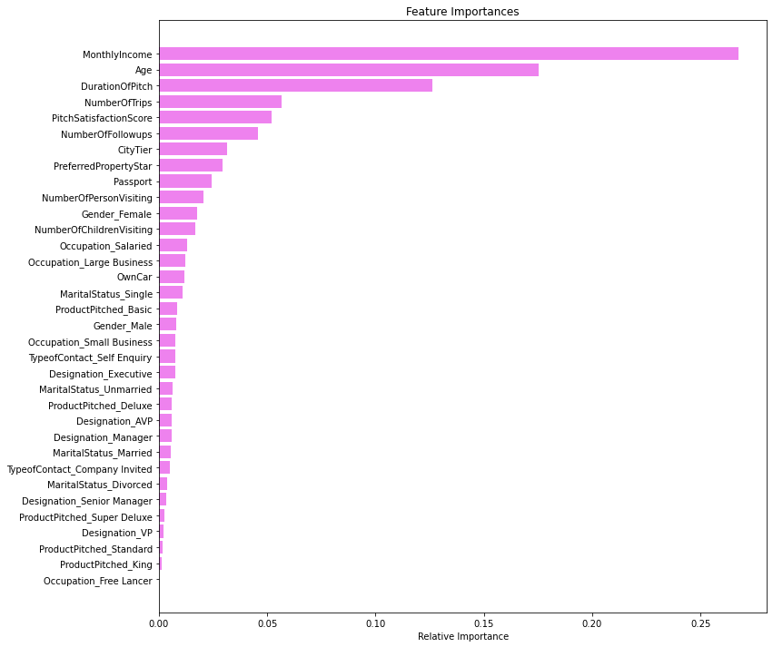

```python
importances = abc_tuned.feature_importances_
indices = np.argsort(importances)
feature_names = list(X.columns)

plt.figure(figsize=(12,12))
plt.title('Feature Importances')
plt.barh(range(len(indices)), importances[indices], color='violet', align='center')
plt.yticks(range(len(indices)), [feature_names[i] for i in indices])
plt.xlabel('Relative Importance')
plt.show()
```

### As shown above, Monthly Income, Age and Duration of Pitch seems to be the critical factors as per Ada Boost Tuned model